# Week Five Part 2 - Document Classification

Brian K. Liles

July 7, 2019

# Overview

It can be useful to be able to classify new “test” documents using already classified “training” documents. A common example is using a corpus of labeled spam and ham (non-spam) e-mails to predict whether or not a new document is spam.

# Goal

For this assignment I will be using the **spam** data set, which was downloaded from www.kaggle.com

# Data

Data was copied from **Kaggle** and added to the github page listed within the **read.csv** statement.

```r
spam <- read.csv("https://raw.githubusercontent.com/LilesB/Data-620/master/spam.csv", header=TRUE, sep = ",", quote = '\"\"', stringsAsFactors=FALSE)
```

Using the **glimpse** function from the **tidyverse** we will look at the **spam** dataset

```r
glimpse(spam)
```

```
## Observations: 5,572
## Variables: 5
## $ v1  <chr> "ham", "ham", "spam", "ham", "ham", "spam", "ham", "ham", ...
## $ v2  <chr> "Go until jurong point, crazy.. Available only in bugis n ...
## $ X   <chr> "", "", "", "", "", "", "", "", "", "", "", "", "", "", ""...
## $ X.1 <chr> "", "", "", "", "", "", "", "", "", "", "", "", "", "", ""...
## $ X.2 <chr> "", "", "", "", "", "", "", "", "", "", "", "", "", "", ""...
```

Based off the information provided by the **glimpse** function, we will remove the last three variables.

```r
spam <- spam %>%
    select(v1,v2)

glimpse(spam)
```

```
## Observations: 5,572
## Variables: 2
## $ v1 <chr> "ham", "ham", "spam", "ham", "ham", "spam", "ham", "ham", "...
## $ v2 <chr> "Go until jurong point, crazy.. Available only in bugis n g...
```

Now we have a manageable data set with 5,572 observations and 2 variables to work with. Next, we will change the names of the columns.

```r
colnames(spam) <- c("email","contents")
glimpse(spam)
```

```
## Observations: 5,572
## Variables: 2
## $ email    <chr> "ham", "ham", "spam", "ham", "ham", "spam", "ham", "h...
## $ contents <chr> "Go until jurong point, crazy.. Available only in bug...
```

Next, we will use the **table** function to determine the tally of ham vs spam

```r
cat("Frequency of Ham & Spam Emails","\n")
```

```
## Frequency of Ham & Spam Emails
```

```r
table(spam$email)
```

```
##
##  ham spam
## 4825  747
```

To create a visual, we will utilize the **ggplot** package to view a bar chart of the data

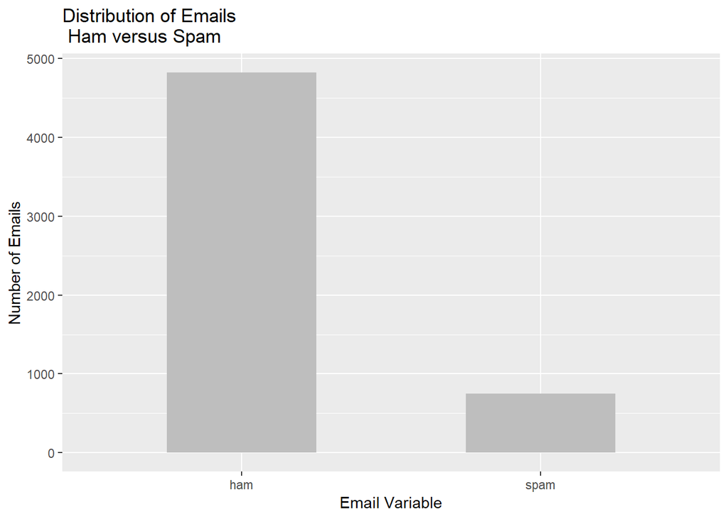

```r
ggplot(data = spam, aes(x = email)) +
  geom_bar(fill = "gray", width = 0.5) +
  xlab("Email Variable") +
  ylab("Number of Emails") +
  ggtitle("Distribution of Emails \n Ham versus Spam")
```

# Training & Test Data Sets

```r
spamTrain <- spam[1:4458,]
spamTest <- spam[4458:nrow(spam),]
```

```r
# check the allocation of spam/no spam data for the training data set
table(spamTrain$email)
```

```
##
##  ham spam
## 3856  602
```

Here we see that 3,856 ham emails and 602 spam emails

```r
# check the allocation of spam/no spam data for the testing data set
table(spamTest$email)
```

```
##
##  ham spam
##  970  145
```

Here we see that 970 ham emails and 145 spam emails

# Naive Bayes Classifier

According to https://towardsdatascience.com/introduction-to-naive-bayes-classification-4cffabb1ae54 **Naive Bayes** classifiers have been especially popular for text classification, and are a traditional solution for problems such as spam detection.

With the **quanteda** package, our first step is to create a corpus based on the **content** column

```r
# construct a corpus object based on data in the content column
contentCorpus <- corpus(spam$contents)

# assign value to the email column
docvars(contentCorpus) <- spam$email
```

Next, we will create a document-feature matrix based off **contentCorpus**

```r
dfm <- dfm(contentCorpus, tolower=TRUE)

# set the minimum and maximum frequencies
dfm <- dfm_trim(dfm, min_docfreq = 3)

dfm <- dfm_weight(dfm)
```

```r
dfmTrain <- dfm[1:4458,]
dfmTest <- dfm[4458:nrow(spam),]
```

We can now run the Naive Bayes classifier

```r
(naiveBayes <- textmodel_nb(dfmTrain,spamTrain[,1]))
```

```
##
## Call:
## textmodel_nb.dfm(x = dfmTrain, y = spamTrain[, 1])
##
## Distribution: multinomial; prior: uniform; smoothing value: 1; 4458 training documents; 2908 fitted features.
```

Next, we will run a prediction utilizing the **predict** function

```r
prediction <- predict(naiveBayes,dfmTest)
```

Next, using the **table** function we will view the predictions

```r
table(prediction, actual = spamTest[,1])
```

```
##           actual
## prediction ham spam
##       ham  950    6
##       spam  20  139
```

Lastly, we will check the accuracy of the model by using the **pROC** package and also checking the accuracy of the test

```r
mean(prediction == spamTest[,1])*100
```

```
## [1] 97.66816
```

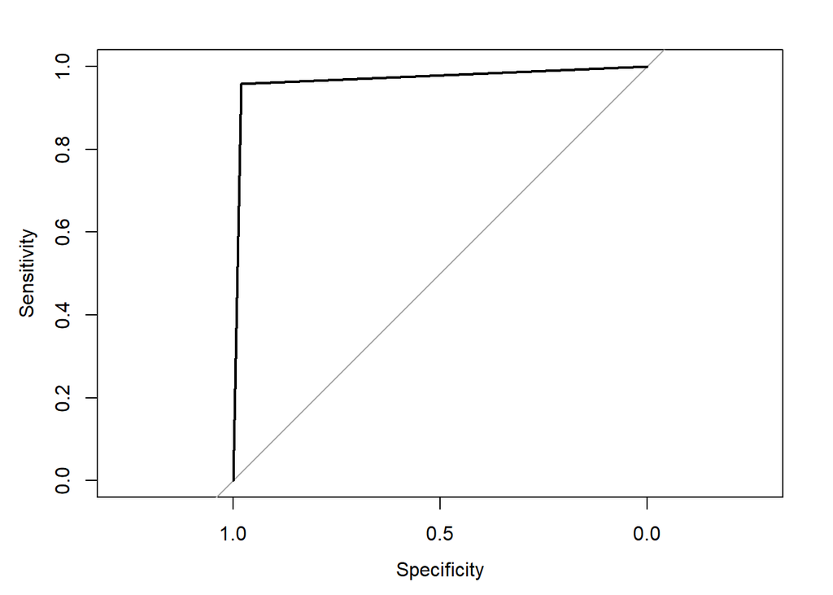

```r
predictNum <- ifelse(prediction == "spam",1,2)
aucTest <- roc(as.factor(spamTest[,1]),predictNum)
plot(aucTest)
```